# Movie Revenue Analysis and Prediction

## Clustring and Vanila Neural Networks

**Author:** Sepehr Barekati

## Overview

This notebook strictly implements a clustering analysis and revenue prediction pipeline for the movies metadata dataset. It is divided into three main phases:

1. **Exploratory Data Analysis (EDA) & Data Cleaning:** Initial data inspection, summary statistics generation, and missing value removal. It includes visual distribution and relationship analysis using histograms, boxplots, scatter plots, and correlation heatmaps.
2. **Clustering Analysis:** Feature normalization and grouping of movies based on budget, runtime, and vote average using K-Means and Hierarchical (Agglomerative) clustering. This includes hyperparameter selection for the optimal number of clusters using inertia (the elbow method) and silhouette scores.
3. **Predictive Modeling:** Train-validation-test splitting and feature scaling, followed by the construction and training of a deep fully connected neural network to predict movie revenue. The model's performance is ultimately evaluated using Mean Squared Error (MSE) and the coefficient of determination ($R^{2}$).

```python
import numpy as np
import pandas as pd
import matplotlib.pyplot as plt
import seaborn as sns

sns.set_theme(style="whitegrid")
```

```python
df = pd.read_csv('movies_metadata.csv')
```

### Exploratory Data Analysis (EDA)

#### 1. Initial Data Inspection

```python
print("Dataset has {} rows and {} columns".format(df.shape[0], df.shape[1]))
print("Data Head:")
display(df.head(5))

print("Data Description:")
display(df.describe())

print("Missing Values:")
display(df.isnull().sum())
```

```
Dataset has 45466 rows and 24 columns
Data Head:
```

|  | adult | belongs_to_collection | budget | genres | homepage | id | imdb_id | original_language | original_title | overview | ... | release_date | revenue | runtime | spoken_languages | status | tagline | title | video | vote_average | vote_count |
| --- | --- | --- | --- | --- | --- | --- | --- | --- | --- | --- | --- | --- | --- | --- | --- | --- | --- | --- | --- | --- | --- |
| 0 | False | {'id': 10194, 'name': 'Toy Story Collection', ... | 30000000 | [{'id': 16, 'name': 'Animation'}, {'id': 35, '... | http://toystory.disney.com/toy-story | 862 | tt0114709 | en | Toy Story | Led by Woody, Andy's toys live happily in his ... | ... | 1995-10-30 | 373554033.0 | 81.0 | [{'iso_639_1': 'en', 'name': 'English'}] | Released | NaN | Toy Story | False | 7.7 | 5415.0 |
| 1 | False | NaN | 65000000 | [{'id': 12, 'name': 'Adventure'}, {'id': 14, '... | NaN | 8844 | tt0113497 | en | Jumanji | When siblings Judy and Peter discover an encha... | ... | 1995-12-15 | 262797249.0 | 104.0 | [{'iso_639_1': 'en', 'name': 'English'}, {'iso... | Released | Roll the dice and unleash the excitement! | Jumanji | False | 6.9 | 2413.0 |
| 2 | False | {'id': 119050, 'name': 'Grumpy Old Men Collect... | 0 | [{'id': 10749, 'name': 'Romance'}, {'id': 35, ... | NaN | 15602 | tt0113228 | en | Grumpier Old Men | A family wedding reignites the ancient feud be... | ... | 1995-12-22 | 0.0 | 101.0 | [{'iso_639_1': 'en', 'name': 'English'}] | Released | Still Yelling. Still Fighting. Still Ready for... | Grumpier Old Men | False | 6.5 | 92.0 |
| 3 | False | NaN | 16000000 | [{'id': 35, 'name': 'Comedy'}, {'id': 18, 'nam... | NaN | 31357 | tt0114885 | en | Waiting to Exhale | Cheated on, mistreated and stepped on, the wom... | ... | 1995-12-22 | 81452156.0 | 127.0 | [{'iso_639_1': 'en', 'name': 'English'}] | Released | Friends are the people who let you be yourself... | Waiting to Exhale | False | 6.1 | 34.0 |
| 4 | False | {'id': 96871, 'name': 'Father of the Bride Col... | 0 | [{'id': 35, 'name': 'Comedy'}] | NaN | 11862 | tt0113041 | en | Father of the Bride Part II | Just when George Banks has recovered from his ... | ... | 1995-02-10 | 76578911.0 | 106.0 | [{'iso_639_1': 'en', 'name': 'English'}] | Released | Just When His World Is Back To Normal... He's ... | Father of the Bride Part II | False | 5.7 | 173.0 |

5 rows × 24 columns

```
Data Description:
```

|  | revenue | runtime | vote_average | vote_count |
| --- | --- | --- | --- | --- |
| count | 4.546000e+04 | 45203.000000 | 45460.000000 | 45460.000000 |
| mean | 1.120935e+07 | 94.128199 | 5.618207 | 109.897338 |
| std | 6.433225e+07 | 38.407810 | 1.924216 | 491.310374 |
| min | 0.000000e+00 | 0.000000 | 0.000000 | 0.000000 |
| 25% | 0.000000e+00 | 85.000000 | 5.000000 | 3.000000 |
| 50% | 0.000000e+00 | 95.000000 | 6.000000 | 10.000000 |
| 75% | 0.000000e+00 | 107.000000 | 6.800000 | 34.000000 |
| max | 2.787965e+09 | 1256.000000 | 10.000000 | 14075.000000 |

```
Missing Values:
```

```
adult                        0
belongs_to_collection    40972
budget                       0
genres                       0
homepage                 37684
id                           0
imdb_id                     17
original_language           11
original_title               0
overview                   954
popularity                   5
poster_path                386
production_companies         3
production_countries         3
release_date                87
revenue                      6
runtime                    263
spoken_languages             6
status                      87
tagline                  25054
title                        6
video                        6
vote_average                 6
vote_count                   6
dtype: int64
```

#### 2. Data Cleaning

```python
df_clean = df.copy()
```

```python
# Removing columns with more than 50% missing values
threshold = len(df) * 0.5
df_clean = df.dropna(thresh=threshold, axis=1)
print("After removing columns with more than 50% missing values, the dataset has {} rows and {} columns".format(df_clean.shape[0], df_clean.shape[1]))
print("--------------------------------------------------------------------------------------------------------------")

# Removing missing values in 'budget' and 'revenue' columns that are 0 and 0.0
# ensure numeric types then remove rows with zero budget or revenue
df_clean['budget'] = pd.to_numeric(df_clean['budget'], errors='coerce')
df_clean['revenue'] = pd.to_numeric(df_clean['revenue'], errors='coerce')
df_clean = df_clean[(df_clean['budget'] > 0) & (df_clean['revenue'] > 0)]
print("After removing rows with 0 and 0.0 in 'budget' and 'revenue' columns, the dataset has {} rows and {} columns".format(df_clean.shape[0], df_clean.shape[1]))
print("--------------------------------------------------------------------------------------------------------------")

# Removing columns as they are not useful for analysis
df_clean = df_clean.drop(columns=['id', 'imdb_id', 'genres', 'overview', 'production_companies', 'production_countries', 'spoken_languages', 'poster_path', 'title', 'release_date', 'status'])
print("After removing unnecessary columns, the dataset has {} rows and {} columns".format(df_clean.shape[0], df_clean.shape[1]))
print("--------------------------------------------------------------------------------------------------------------")

# Removing all rows with missing values
df_clean = df_clean.dropna(axis=0)
print("After removing all rows with missing values, the dataset has {} rows and {} columns".format(df_clean.shape[0], df_clean.shape[1]))
print("--------------------------------------------------------------------------------------------------------------")

# Removing duplicates
df_clean = df_clean.drop_duplicates()
print("After removing duplicates, the dataset has {} rows and {} columns".format(df_clean.shape[0], df_clean.shape[1]))
print("--------------------------------------------------------------------------------------------------------------")
```

```
After removing columns with more than 50% missing values, the dataset has 45466 rows and 21 columns
--------------------------------------------------------------------------------------------------------------
After removing rows with 0 and 0.0 in 'budget' and 'revenue' columns, the dataset has 5381 rows and 21 columns
--------------------------------------------------------------------------------------------------------------
After removing unnecessary columns, the dataset has 5381 rows and 10 columns
--------------------------------------------------------------------------------------------------------------
After removing all rows with missing values, the dataset has 5380 rows and 10 columns
--------------------------------------------------------------------------------------------------------------
After removing duplicates, the dataset has 5380 rows and 10 columns
--------------------------------------------------------------------------------------------------------------
```

#### 3. Visualization

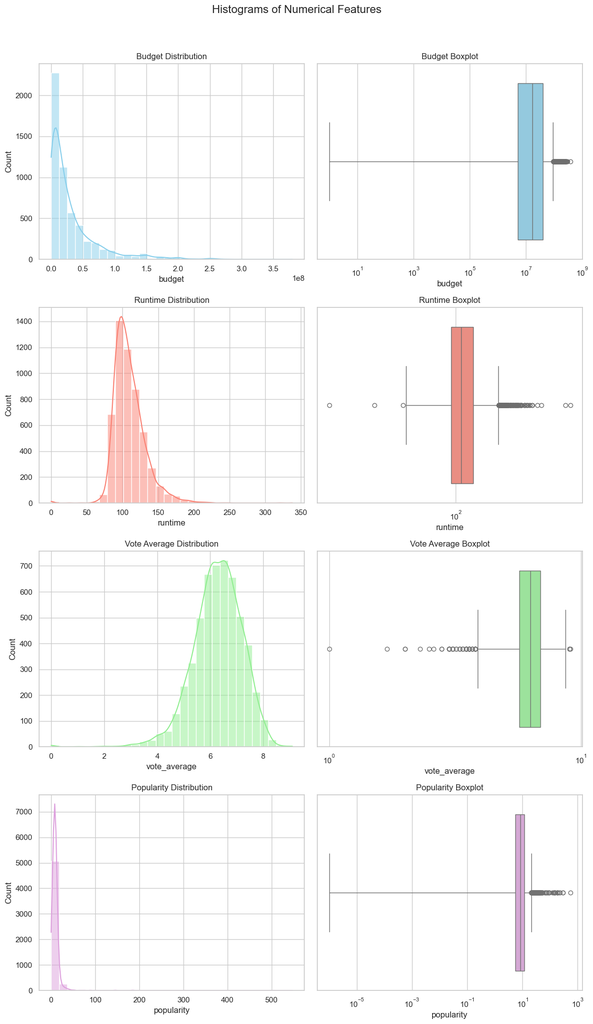

```python
# List of features to visualize
features = ['budget', 'runtime', 'vote_average', 'popularity']

# Ensure the columns are numeric (often necessary after loading raw CSVs)
for col in features:
    df_clean[col] = pd.to_numeric(df_clean[col], errors='coerce')

fig, axes = plt.subplots(4, 2, figsize=(12, 20))
fig.suptitle('Histograms of Numerical Features', fontsize=16, y=1.02)

# Budget
sns.histplot(df_clean['budget'], bins=30, ax=axes[0, 0], kde=True, color='skyblue')
axes[0, 0].set_title('Budget Distribution')

sns.boxplot(x=df_clean['budget'], ax=axes[0, 1], color='skyblue')
axes[0, 1].set_title('Budget Boxplot')
axes[0, 1].set_xscale('log') # Log scale handles extreme outliers

# Runtime
sns.histplot(df_clean['runtime'], bins=30, ax=axes[1, 0], kde=True, color='salmon')
axes[1, 0].set_title('Runtime Distribution')

sns.boxplot(x=df_clean['runtime'], ax=axes[1, 1], color='salmon')
axes[1, 1].set_title('Runtime Boxplot')
axes[1, 1].set_xscale('log') # Log scale handles extreme outliers

# Vote Average
sns.histplot(df_clean['vote_average'], bins=30, ax=axes[2, 0], kde=True, color='lightgreen')
axes[2, 0].set_title('Vote Average Distribution')

sns.boxplot(x=df_clean['vote_average'], ax=axes[2, 1], color='lightgreen')
axes[2, 1].set_title('Vote Average Boxplot')
axes[2, 1].set_xscale('log') # Log scale handles extreme outliers

# Popularity
sns.histplot(df_clean['popularity'], bins=30, ax=axes[3, 0], kde=True, color='plum')
axes[3, 0].set_title('Popularity Distribution')

sns.boxplot(x=df_clean['popularity'], ax=axes[3, 1], color='plum')
axes[3, 1].set_title('Popularity Boxplot')
axes[3, 1].set_xscale('log') # Log scale handles extreme outliers
# Adjust layout so plots don't overlap
plt.tight_layout()
plt.show()
```

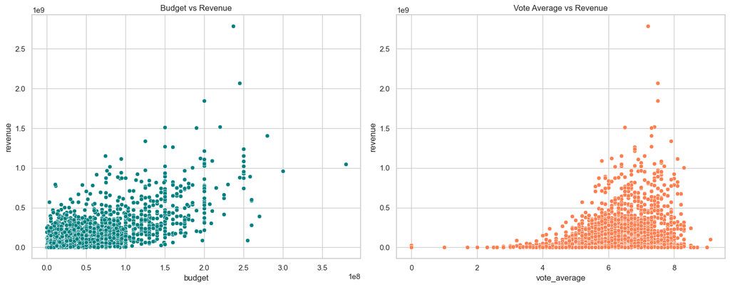

```python
# scatter plot for budget vs revenue and vote_average vs revenue
fig, axes = plt.subplots(1, 2, figsize=(15, 6))
sns.scatterplot(x='budget', y='revenue', data=df_clean, ax=axes[0], color='teal')
axes[0].set_title('Budget vs Revenue')

sns.scatterplot(x='vote_average', y='revenue', data=df_clean, ax=axes[1], color='coral')
axes[1].set_title('Vote Average vs Revenue')

plt.tight_layout()
plt.show()
```

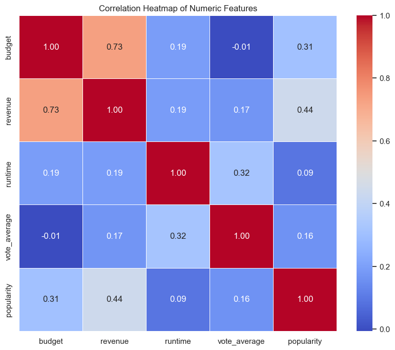

```python
# correlation heatmap for numeric features
numeric_cols = ['budget', 'revenue', 'runtime', 'vote_average', 'popularity']
corr_matrix = df_clean[numeric_cols].corr()

plt.figure(figsize=(10, 8))
sns.heatmap(corr_matrix, annot=True, cmap='coolwarm', fmt=".2f", linewidths=0.5)
plt.title('Correlation Heatmap of Numeric Features')
plt.show()
```

### Clustering Analysis

#### 1. Feature Normalization

```python
from sklearn.preprocessing import StandardScaler
from sklearn.cluster import KMeans, AgglomerativeClustering
from sklearn.metrics import silhouette_score
```

```python
# 1. Feature Normalization
features_to_cluster = ['budget', 'runtime', 'vote_average']
X = df_clean[features_to_cluster].copy()

# Initialize scaler and transform the features
scaler = StandardScaler()
X_scaled = scaler.fit_transform(X)
```

#### 2. K-Means Clustering Evaluation

```python
# 2. K-Means Clustering Evaluation (k=2 to 10)
k_values = range(2, 11)
kmeans_inertia = []
kmeans_silhouette = []

for k in k_values:
    # Initialize and fit K-Means
    kmeans = KMeans(n_clusters=k, random_state=42, n_init=10)
    kmeans_labels = kmeans.fit_predict(X_scaled)

    # Store metrics
    kmeans_inertia.append(kmeans.inertia_)
    kmeans_silhouette.append(silhouette_score(X_scaled, kmeans_labels))
```

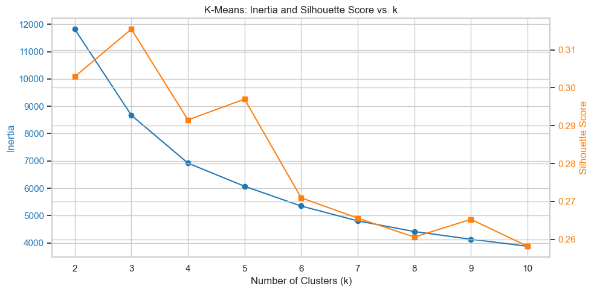

```python
# Plotting K-Means Metrics
fig, ax1 = plt.subplots(figsize=(10, 5))

# Plot Inertia (Left Y-axis)
color = 'tab:blue'
ax1.set_xlabel('Number of Clusters (k)')
ax1.set_ylabel('Inertia', color=color)
ax1.plot(k_values, kmeans_inertia, marker='o', color=color, label='Inertia')
ax1.tick_params(axis='y', labelcolor=color)

# Plot Silhouette Score (Right Y-axis)
ax2 = ax1.twinx()
color = 'tab:orange'
ax2.set_ylabel('Silhouette Score', color=color)
ax2.plot(k_values, kmeans_silhouette, marker='s', color=color, label='Silhouette Score')
ax2.tick_params(axis='y', labelcolor=color)

plt.title('K-Means: Inertia and Silhouette Score vs. k')
fig.tight_layout()
plt.show()
```

#### 3. K-Means Assignment

```python
# Apply the optimal K-Means clustering
OPTIMAL_K_KMEANS = 3
final_kmeans = KMeans(n_clusters=OPTIMAL_K_KMEANS, random_state=42, n_init=10)

# Store labels as a new column for future use
df_clean['kmeans_cluster'] = final_kmeans.fit_predict(X_scaled)
```

#### 4. Hierarchical Clustering Evaluation

```python
hierarchical_inertia = []
hierarchical_silhouette = []

for k in k_values:
    # Fit Agglomerative Clustering
    agg_clustering = AgglomerativeClustering(n_clusters=k, metric='euclidean', linkage='ward')
    agg_labels = agg_clustering.fit_predict(X_scaled)

    # Compute Silhouette Score using Hierarchical labels
    hierarchical_silhouette.append(silhouette_score(X_scaled, agg_labels, metric='euclidean'))

    # Fit a dummy K-Means strictly to get the inertia for this specific k
    dummy_kmeans = KMeans(n_clusters=k, random_state=42, n_init=10)
    dummy_kmeans.fit(X_scaled)
    hierarchical_inertia.append(dummy_kmeans.inertia_)
```

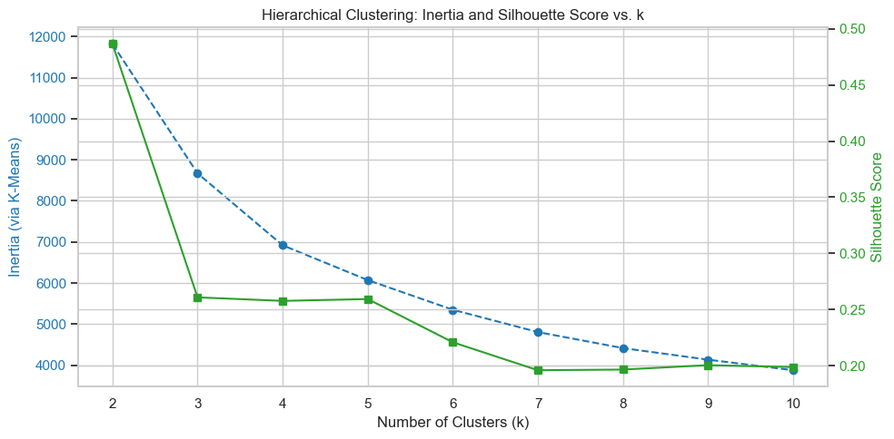

```python
# Plot the Hierarchical Metrics
fig, ax1 = plt.subplots(figsize=(10, 5))

color = 'tab:blue'
ax1.set_xlabel('Number of Clusters (k)')
ax1.set_ylabel('Inertia (via K-Means)', color=color)
ax1.plot(k_values, hierarchical_inertia, marker='o', color=color, linestyle='--')
ax1.tick_params(axis='y', labelcolor=color)

ax2 = ax1.twinx()
color = 'tab:green'
ax2.set_ylabel('Silhouette Score', color=color)
ax2.plot(k_values, hierarchical_silhouette, marker='s', color=color)
ax2.tick_params(axis='y', labelcolor=color)

plt.title('Hierarchical Clustering: Inertia and Silhouette Score vs. k')
fig.tight_layout()
plt.show()
```

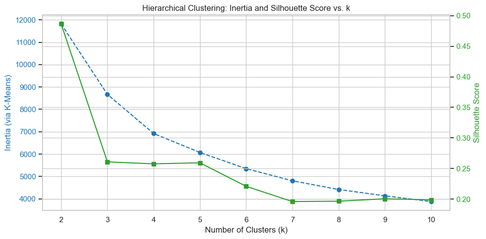

```python
# Plotting Hierarchical Metrics
fig, ax1 = plt.subplots(figsize=(10, 5))

# Plot Inertia (Left Y-axis)
color = 'tab:blue'
ax1.set_xlabel('Number of Clusters (k)')
ax1.set_ylabel('Inertia (via K-Means)', color=color)
ax1.plot(k_values, hierarchical_inertia, marker='o', color=color, linestyle='--')
ax1.tick_params(axis='y', labelcolor=color)

# Plot Silhouette Score (Right Y-axis)
ax2 = ax1.twinx()
color = 'tab:green'
ax2.set_ylabel('Silhouette Score', color=color)
ax2.plot(k_values, hierarchical_silhouette, marker='s', color=color)
ax2.tick_params(axis='y', labelcolor=color)

plt.title('Hierarchical Clustering: Inertia and Silhouette Score vs. k')
fig.tight_layout()
plt.show()
```

#### 5. Hierarchical Assignment

```python
# Apply the optimal Hierarchical clustering
OPTIMAL_K_HIERARCHICAL = 2
final_hierarchical = AgglomerativeClustering(
    n_clusters=OPTIMAL_K_HIERARCHICAL,
    metric='euclidean',
    linkage='ward'
)

# Store labels as a new column
df_clean['hierarchical_cluster'] = final_hierarchical.fit_predict(X_scaled)

# Display the final clustered dataframe structure
df_clean[['budget', 'runtime', 'vote_average', 'kmeans_cluster', 'hierarchical_cluster']].head()
```

|  | budget | runtime | vote_average | kmeans_cluster | hierarchical_cluster |
| --- | --- | --- | --- | --- | --- |
| 0 | 30000000.0 | 81.0 | 7.7 | 0 | 0 |
| 1 | 65000000.0 | 104.0 | 6.9 | 0 | 0 |
| 3 | 16000000.0 | 127.0 | 6.1 | 0 | 0 |
| 5 | 60000000.0 | 170.0 | 7.7 | 0 | 0 |
| 8 | 35000000.0 | 106.0 | 5.5 | 1 | 0 |

### Neural Network for Revenue Prediction

```python
from sklearn.model_selection import train_test_split
from sklearn.preprocessing import StandardScaler

# Ensure only numerical features are used for the Neural Network.
# Drop the target variable 'revenue' and any non-numeric columns like movie titles.
# Note: If you want to include the cluster labels from Phase 2, leave them in.
numeric_df = df_clean.select_dtypes(include=['float64', 'int64', 'int32'])
X = numeric_df.drop(columns=['revenue'])
y = numeric_df['revenue']
```

#### 1. Data Splitting (70% Train, 15% Val, 15% Test)

```python
# First Split: Separate 70% for training and 30% for a temporary set
X_train, X_temp, y_train, y_temp = train_test_split(
    X, y, test_size=0.30, random_state=42
)

# Second Split: Divide the remaining 30% equally (50% of 30% = 15% each)
X_val, X_test, y_val, y_test = train_test_split(
    X_temp, y_temp, test_size=0.50, random_state=42
)

# Print the shapes to verify the correct split percentages
print(f"Training set: {X_train.shape[0]} samples")
print(f"Validation set: {X_val.shape[0]} samples")
print(f"Test set: {X_test.shape[0]} samples")
```

```
Training set: 3766 samples
Validation set: 807 samples
Test set: 807 samples
```

#### 2. Feature Normalization

Feature & Target Normalization

```python
# Scale the Input Features
feature_scaler = StandardScaler()
X_train_scaled = feature_scaler.fit_transform(X_train)
X_val_scaled = feature_scaler.transform(X_val)
X_test_scaled = feature_scaler.transform(X_test)


# Scale the Target Variable (Revenue) to stabilize training
target_scaler = StandardScaler()
y_train_scaled = target_scaler.fit_transform(y_train.values.reshape(-1, 1))
y_val_scaled = target_scaler.transform(y_val.values.reshape(-1, 1))
y_test_scaled = target_scaler.transform(y_test.values.reshape(-1, 1))
```

#### 3. Neural Network Architecture

```python
from keras.models import Sequential
from keras.layers import Dense, InputLayer

# Assuming X_train_scaled from the previous step is available
number_of_features = X_train_scaled.shape[1]

model = Sequential([
    InputLayer(input_shape=(number_of_features,)),
    Dense(64, activation='relu'),
    Dense(32, activation='relu'),
    Dense(1, activation='linear')
])

print("--- Model Architecture ---")
model.summary()
from tensorflow.keras.layers import Dense, InputLayer

# Assuming X_train_scaled from the previous step is available
# Calculate the number of input features
number_of_features = X_train_scaled.shape[1]

model = Sequential([
    InputLayer(input_shape=(number_of_features,)),
    Dense(64, activation='relu'),
    Dense(32, activation='relu'),
    Dense(1, activation='linear')
])

print("--- Model Architecture ---")
model.summary()
```

[output not shown]

#### Model Architecture Summary

- **Layer 1 (`dense`)**: This is the first hidden layer. The output shape of `(None, 64)` confirms it has **64 neurons**. The `None` dimension indicates that the model can accept any batch size during training. This layer contains 512 trainable parameters (weights and biases), which tells us that the input data contains exactly **7 features** (since $7 \times 64 \text{ weights} + 64 \text{ biases} = 512$).
- **Layer 2 (`dense_1`)**: This is the second hidden layer with **32 neurons**. It takes the 64 outputs from the previous layer, resulting in 2,080 parameters ($64 \times 32 \text{ weights} + 32 \text{ biases}$).
- **Layer 3 (`dense_2`)**: This is the final output layer. It consists of a **single neuron** designed to output the continuous predicted revenue value. It has 33 parameters ($32 \text{ weights} + 1 \text{ bias}$).

**Overall Capacity**: The network has a total of **2,625 trainable parameters**. Since there are no frozen layers, all 2,625 parameters will be updated by the Adam optimizer during training to minimize the Mean Squared Error.

#### 4. Training Configuration

```python
# 1. Compile the model
# Setting the optimizer to 'adam' and loss function to Mean Squared Error ('mse')
model.compile(
    optimizer='adam',
    loss='mse'
)
```

We will use 100 epochs (the upper end of the 50-100 range) and a batch size of 32.

We also pass in the validation set we created earlier so the model can be monitored on unseen data at the end of each epoch.

```python
# 2. Train the model

history = model.fit(
    X_train_scaled,
    y_train,
    epochs=100,
    batch_size=32,
    validation_data=(X_val_scaled, y_val),
    verbose=1 # Set to 1 to see the training progress bar for each epoch
)
```

[output not shown]

#### 5. Evaluation

```python
from sklearn.metrics import mean_squared_error, r2_score
```

```python
# Generate predictions on the unseen test set
y_pred = model.predict(X_test_scaled)

# Calculate Mean Squared Error (MSE)
test_mse = mean_squared_error(y_test, y_pred)

# Calculate Coefficient of determination (R^2)
test_r2 = r2_score(y_test, y_pred)

# Report the metrics
print("--- Final Model Evaluation on Test Set ---")
print(f"Mean Squared Error (MSE): {test_mse:,.2f}")
print(f"Coefficient of determination (R^2): {test_r2:.4f}")
```

[output not shown]